# 004_troubleshooting.Rmd

Dan MacLean

07/01/2022

## Load original data from Paul

First step is to load the data that Paul provided, specifically the file `M_oryzae_PRM_TEMP_07_with_spectra_refined_Guy11_deltaPmk1_timecourse_for_informatics.xlsx`

```r
xlp <- here::here("raw", "M_oryzae_PRM_TEMP_07_with_spectra_refined_Guy11_deltaPmk1_timecourse_for_informatics.xlsx")
readxl::excel_sheets(xlp)
```

```
## [1] "Data_for_informatics"
```

```r
xld <- readxl::read_excel(xlp, sheet="Data_for_informatics")
xld
```

```
## # A tibble: 20,520 × 10
##    `Molecule List Na… `Protein Description`   `Molecule List … `Peptide Modifie…
##    <chr>              <chr>                   <chr>            <chr>
##  1 gi|145601729|ref|… hypothetical protein M… (blank)          KLS[+80]ASGS[+80…
##  2 gi|145601729|ref|… hypothetical protein M… (blank)          KLS[+80]ASGS[+80…
##  3 gi|145601729|ref|… hypothetical protein M… (blank)          KLS[+80]ASGS[+80…
##  4 gi|145601729|ref|… hypothetical protein M… (blank)          KLS[+80]ASGS[+80…
##  5 gi|145601729|ref|… hypothetical protein M… (blank)          KLS[+80]ASGS[+80…
##  6 gi|145601729|ref|… hypothetical protein M… (blank)          KLS[+80]ASGS[+80…
##  7 gi|145601729|ref|… hypothetical protein M… (blank)          KLS[+80]ASGS[+80…
##  8 gi|145601729|ref|… hypothetical protein M… (blank)          KLS[+80]ASGS[+80…
##  9 gi|145601729|ref|… hypothetical protein M… (blank)          KLS[+80]ASGS[+80…
## 10 gi|145601729|ref|… hypothetical protein M… (blank)          KLS[+80]ASGS[+80…
## # … with 20,510 more rows, and 6 more variables: Precursor Note <chr>,
## #   Molecule Note <chr>, Precursor Mz <dbl>, Precursor Charge <dbl>,
## #   Replicate Name <chr>, Total Area <dbl>
```

### ‘Tidy’ the data

Next step is to move the data from the current format into the ‘tidy’ format needed for any analysis

```r
cleaned <- xld %>%
  dplyr::select( `Replicate Name`, `Molecule List Name`, `Total Area`, `Peptide Modified Sequence`) %>%
  dplyr::rename_with(tolower) %>%
  dplyr::rename_with( ~ gsub(" ", "_", .x)) %>%
  tidyr::separate(replicate_name, into = c("genotype", "timepoint", "bio_rep", "tech_rep", "misc"), sep=", ") %>%
  dplyr::mutate(
    timepoint = as.numeric(dplyr::if_else(timepoint == 'Spores', "0", timepoint)),
    bio_rep = as.numeric(stringr::str_sub(bio_rep, 2,-1)),
    tech_rep = as.numeric(stringr::str_sub(tech_rep, 2,-1))
  ) %>%
  dplyr::select(molecule_list_name, peptide_modified_sequence, genotype, timepoint, bio_rep, tech_rep, total_area)

cleaned
```

```
## # A tibble: 20,520 × 7
##    molecule_list_name    peptide_modified_s… genotype timepoint bio_rep tech_rep
##    <chr>                 <chr>               <chr>        <dbl>   <dbl>    <dbl>
##  1 gi|145601729|ref|XP_… KLS[+80]ASGS[+80]P… Guy11            0       1        1
##  2 gi|145601729|ref|XP_… KLS[+80]ASGS[+80]P… Guy11            0       1        2
##  3 gi|145601729|ref|XP_… KLS[+80]ASGS[+80]P… Guy11            0       2        1
##  4 gi|145601729|ref|XP_… KLS[+80]ASGS[+80]P… Guy11            0       2        2
##  5 gi|145601729|ref|XP_… KLS[+80]ASGS[+80]P… Guy11            0       3        1
##  6 gi|145601729|ref|XP_… KLS[+80]ASGS[+80]P… Guy11            0       3        2
##  7 gi|145601729|ref|XP_… KLS[+80]ASGS[+80]P… Guy11            1       1        1
##  8 gi|145601729|ref|XP_… KLS[+80]ASGS[+80]P… Guy11            1       1        2
##  9 gi|145601729|ref|XP_… KLS[+80]ASGS[+80]P… Guy11            1       2        1
## 10 gi|145601729|ref|XP_… KLS[+80]ASGS[+80]P… Guy11            1       2        2
## # … with 20,510 more rows, and 1 more variable: total_area <dbl>
```

The data is large, so for this close walkthrough, I’ll use a smaller subset. Having looked ahead I know that the peptide `"AAEEDVTTT[+80]PR"` has sparse information, that `"KLS[+80]ASGS[+80]PGSVNLGR"` has better information, that `"QTRT[+80]PS[+80]PASNGPAPLGVAEGPITPR"` has full information, that `"RLS[+80]FGDDQEER"` is of interest from Paul’s PPT, as is `VTS1` `"SNDNSGQNPLS[+80]PGM[+16]ISPNVVM[+16]VDEHGR"`. So I’ll pull these out and use them.

```r
keepers <- c("AAEEDVTTT[+80]PR","KLS[+80]ASGS[+80]PGSVNLGR","QTRT[+80]PS[+80]PASNGPAPLGVAEGPITPR",
             "RLS[+80]FGDDQEER", "SNDNSGQNPLS[+80]PGM[+16]ISPNVVM[+16]VDEHGR")

cleaned_small <- dplyr::filter(cleaned, peptide_modified_sequence %in% keepers)
dplyr::arrange(cleaned_small, desc(total_area) )
```

```
## # A tibble: 360 × 7
##    molecule_list_name  peptide_modified_seq… genotype timepoint bio_rep tech_rep
##    <chr>               <chr>                 <chr>        <dbl>   <dbl>    <dbl>
##  1 MGG_12865T0         RLS[+80]FGDDQEER      Guy11            6       3        2
##  2 MGG_12865T0         RLS[+80]FGDDQEER      Guy11            6       1        2
##  3 gi|39976863|ref|XP… SNDNSGQNPLS[+80]PGM[… Guy11            6       3        2
##  4 MGG_12865T0         RLS[+80]FGDDQEER      dpmk1            6       2        2
##  5 MGG_12865T0         RLS[+80]FGDDQEER      Guy11            4       3        2
##  6 MGG_12865T0         RLS[+80]FGDDQEER      Guy11            2       3        2
##  7 MGG_12865T0         RLS[+80]FGDDQEER      dpmk1            4       2        2
##  8 MGG_12865T0         RLS[+80]FGDDQEER      dpmk1            2       2        2
##  9 gi|39976863|ref|XP… SNDNSGQNPLS[+80]PGM[… dpmk1            6       2        2
## 10 gi|39976863|ref|XP… SNDNSGQNPLS[+80]PGM[… Guy11            6       3        1
## # … with 350 more rows, and 1 more variable: total_area <dbl>
```

```r
readr::write_csv(cleaned_small, here::here("cleaned", "004_selected_ts_1.csv")) %>% dplyr::select(total_area)
```

```
## # A tibble: 360 × 1
##    total_area
##         <dbl>
##  1   0.00103
##  2   0.00113
##  3   0.000524
##  4   0.000284
##  5  NA
##  6  NA
##  7   0.000393
##  8   0.000167
##  9   0.000330
## 10  NA
## # … with 350 more rows
```

### Load into `pepdiff` data stucture

```r
library(pepdiff)
pdiff <- import_data(here::here("cleaned", "004_selected_ts_1.csv"),
                 gene_id = "molecule_list_name",
                 treatment = "genotype",
                 peptide = "peptide_modified_sequence",
                 seconds = "timepoint")
pdiff
```

```
## # A tibble: 360 × 8
##    id           gene_id    peptide   treatment seconds bio_rep tech_rep    quant
##    <chr>        <chr>      <chr>     <chr>       <dbl> <chr>   <chr>       <dbl>
##  1 gi|14560172… gi|145601… KLS[+80]… Guy11           0 1       1         1.03e-3
##  2 gi|14560172… gi|145601… KLS[+80]… Guy11           0 1       2         1.13e-3
##  3 gi|14560172… gi|145601… KLS[+80]… Guy11           0 2       1         5.24e-4
##  4 gi|14560172… gi|145601… KLS[+80]… Guy11           0 2       2         2.84e-4
##  5 gi|14560172… gi|145601… KLS[+80]… Guy11           0 3       1        NA
##  6 gi|14560172… gi|145601… KLS[+80]… Guy11           0 3       2        NA
##  7 gi|14560172… gi|145601… KLS[+80]… Guy11           1 1       1         3.93e-4
##  8 gi|14560172… gi|145601… KLS[+80]… Guy11           1 1       2         1.67e-4
##  9 gi|14560172… gi|145601… KLS[+80]… Guy11           1 2       1         3.30e-4
## 10 gi|14560172… gi|145601… KLS[+80]… Guy11           1 2       2        NA
## # … with 350 more rows
```

This is where we would normally start from. The first step is to get the data into a matrix for analysis. I’ve been doing this with this function `matrix_data()`. Note that the first step of this is `combine_tech_reps()` which performs the action of replacing any missing tech rep data with any other tech rep data for that sample and bio-rep combination. Strictly speaking it does this by taking the average of all the tech rep for a sample and bio-rep because if there is only one tech rep we get that one value, if there is more than one we get the average of them as expected

```r
library(rlang)
combine_tech_reps <- function(df){
  df %>%
    dplyr::group_by(.data$gene_id, .data$peptide, .data$treatment, .data$seconds, .data$bio_rep) %>%
    dplyr::summarize(mean_tr_quant = mean(.data$quant, na.rm = TRUE) )
}


matrix_data <- function(df){
  df <- combine_tech_reps(df)
  row_info <- dplyr::group_by(df, .data$gene_id, .data$peptide, .data$treatment, .data$seconds, .data$bio_rep) %>%
    dplyr::summarize(col_count = dplyr::n() )

  dm <- df %>%
    tidyr::pivot_wider(names_from = c(.data$treatment, .data$seconds, .data$bio_rep), values_from = .data$mean_tr_quant) %>%
    as.matrix()

  row_info <- dm[,c("gene_id", "peptide")]
  col_info <- colnames(dm[,3:length(colnames(dm))])
  dm <-  matrix(as.numeric(dm[,3:ncol(dm)]), nrow=nrow(dm) )
  colnames(dm) <- col_info
  return(list( row_info = row_info, data = dm ))
}
```

So if we run this code we get a matrix of bio-rep level data for each sample. Note that rownames are consistent across the analysis but not always shown with the data, they are in a separate bit `row_info` shown below too but not *always*

```r
mdata <- matrix_data(pdiff)
mdata$data
```

```
##        dpmk1_0_1    dpmk1_0_2   dpmk1_0_3    dpmk1_1_1    dpmk1_1_2
## [1,] 0.001229286 0.0003157263          NA 0.0003080515 0.0002806290
## [2,] 0.003035265 0.0027082665 2.41783e-04 0.0008760315 0.0020062610
## [3,]          NA           NA          NA           NA           NA
## [4,] 0.000537064 0.0017847892 9.63572e-05 0.0006465552 0.0027545328
## [5,]          NA           NA          NA 0.0009232904 0.0007842194
##         dpmk1_1_3  dpmk1_1.5_1  dpmk1_1.5_2  dpmk1_1.5_3    dpmk1_2_1
## [1,] 0.0003350321 0.0004555553 0.0001574461           NA 0.0002511316
## [2,] 0.0013864871 0.0011309654 0.0006976037 1.953995e-04 0.0012302161
## [3,]           NA           NA           NA           NA           NA
## [4,] 0.0004033864 0.0005462359 0.0021265575 7.998513e-05 0.0010660021
## [5,] 0.0002259952 0.0008516205 0.0018648116 1.656680e-04 0.0005723574
##        dpmk1_2_2    dpmk1_2_3    dpmk1_4_1    dpmk1_4_2    dpmk1_4_3
## [1,]          NA 3.523301e-04 0.0004472841 6.714639e-04 0.0002630847
## [2,] 0.000269719 1.711638e-03 0.0009591751 5.504107e-04 0.0008175470
```

[output cut: 33 more lines]

```r
mdata$row_info
```

```
##      gene_id
## [1,] "gi|145601729|ref|XP_363034.2|"
## [2,] "gi|145602009|ref|XP_359520.2|"
## [3,] "gi|145602328|ref|XP_001403655.1|"
## [4,] "gi|39976863|ref|XP_369819.1|"
## [5,] "MGG_12865T0"
##      peptide
## [1,] "KLS[+80]ASGS[+80]PGSVNLGR"
## [2,] "QTRT[+80]PS[+80]PASNGPAPLGVAEGPITPR"
## [3,] "AAEEDVTTT[+80]PR"
## [4,] "SNDNSGQNPLS[+80]PGM[+16]ISPNVVM[+16]VDEHGR"
## [5,] "RLS[+80]FGDDQEER"
```

Which is a bit easier read if we plot as a heatmap, grey boxes are missing values.

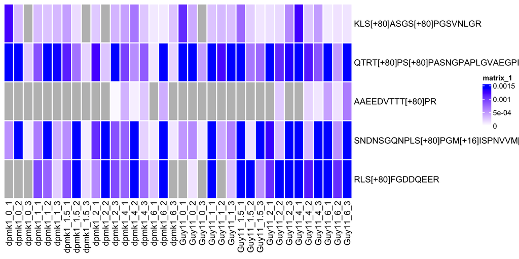

```r
m <- mdata$data
rownames(m) <- mdata$row_info[,'peptide']
colnames(m) <- colnames(mdata$data)
ComplexHeatmap::Heatmap(m, column_order = colnames(m), row_order = rownames(m), rect_gp = grid::gpar(col = "white", lwd = 2 ), col = col_fun )
```

## Replacing missing values

Now we are at the stage for doing comparisons. We’ll select a control and test (Spores (0) vs 1 hr in the genotype Guy11) and process that in the way done in the package. The first step is to find and replace the missing values with the lowest observed peptide values across the whole set. Working out the lowest values is done with the function `min_peptide_values()`

```r
min_peptide_values <- function(d){
  apply(d$data, MARGIN = 1, min, na.rm = TRUE)
}

lowest_vals <- min_peptide_values(mdata)
```

and selecting the columns is done with the function `select_columns_for_contrast()`

```r
select_columns_for_contrast <- function(l, treatment = NA,
                                        t_seconds = NA,
                                        control = NA,
                                        c_seconds = NA){
  td <- paste(treatment, t_seconds, sep = "_")
  td <- paste0("^", td, "$")

  cd <- paste(control, c_seconds, sep = "_")
  cd <- paste0("^", cd, "$")
  cnames_no_biorep <- unlist(lapply(strsplit(colnames(l$data), "_"), function(x) paste0(x[1], "_", x[2])))

  t_ind <- which(stringr::str_detect(cnames_no_biorep, td))
  c_ind <- which(stringr::str_detect(cnames_no_biorep, cd))

  return(list(
    treatment = l$data[,t_ind],
    control = l$data[,c_ind]
  ))
}


  selected_cols <- select_columns_for_contrast(
    mdata,
    treatment = "Guy11",
    t_seconds = 1,
    control = "Guy11",
    c_seconds = 0
  )


selected_cols
```

```
## $treatment
##         Guy11_1_1    Guy11_1_2    Guy11_1_3
## [1,] 0.0002798596 0.0003295988 0.0002979896
## [2,] 0.0016080117 0.0012118765 0.0014762770
## [3,]           NA           NA           NA
## [4,] 0.0022845043 0.0004084508 0.0006268095
## [5,] 0.0013969140           NA 0.0002917353
##
## $control
##         Guy11_0_1    Guy11_0_2    Guy11_0_3
## [1,] 0.0010807707 0.0004039197           NA
## [2,] 0.0028679916 0.0022220345 0.0004708498
## [3,]           NA           NA           NA
## [4,] 0.0004963894 0.0005590420 0.0001115249
## [5,]           NA 0.0001298511           NA
```

Lets quickly plot that as a heatmap

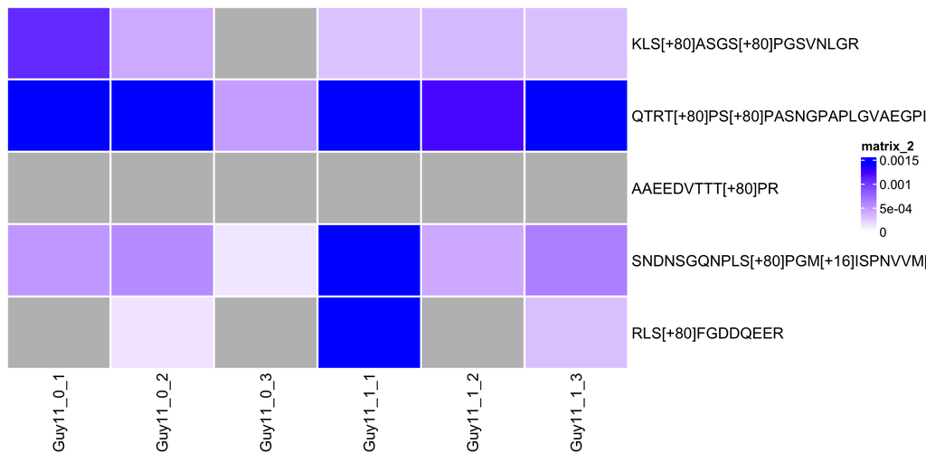

```r
m <- cbind(selected_cols$control, selected_cols$treatment)
rownames(m) <- mdata$row_info[,'peptide']
hm_missing <- ComplexHeatmap::Heatmap(m, column_order = colnames(m), row_order = rownames(m), rect_gp = grid::gpar(col = "white", lwd = 2 ), col = col_fun )
hm_missing
```

And replacing the missing values is done like this

```r
replace_vals <- function(x, lowest_vals){
  to_replace <- which(is.na(x))
  x[to_replace] <- lowest_vals[to_replace]
  return(x)
}

control <- apply(selected_cols$control, MARGIN = 2, replace_vals, lowest_vals)
treatment <- apply(selected_cols$treatment, MARGIN = 2, replace_vals, lowest_vals)

control
```

```
##         Guy11_0_1    Guy11_0_2    Guy11_0_3
## [1,] 1.080771e-03 4.039197e-04 9.174940e-05
## [2,] 2.867992e-03 2.222035e-03 4.708498e-04
## [3,] 3.181009e-05 3.181009e-05 3.181009e-05
## [4,] 4.963894e-04 5.590420e-04 1.115249e-04
## [5,] 1.298511e-04 1.298511e-04 1.298511e-04
```

```r
treatment
```

```
##         Guy11_1_1    Guy11_1_2    Guy11_1_3
## [1,] 2.798596e-04 3.295988e-04 2.979896e-04
## [2,] 1.608012e-03 1.211876e-03 1.476277e-03
## [3,] 3.181009e-05 3.181009e-05 3.181009e-05
## [4,] 2.284504e-03 4.084508e-04 6.268095e-04
## [5,] 1.396914e-03 1.298511e-04 2.917353e-04
```

And a heatmap for the replaced values

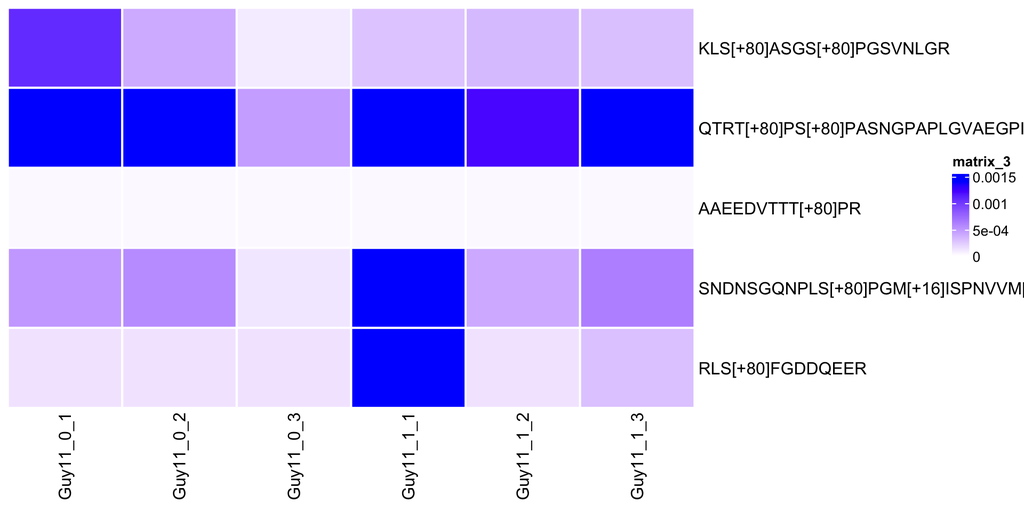

```r
m <- cbind(control, treatment)
rownames(m) <- mdata$row_info[,'peptide']
hm_replaced <- ComplexHeatmap::Heatmap(m, column_order = colnames(m), row_order = rownames(m), rect_gp = grid::gpar(col = "white", lwd = 2 ), col = col_fun )
hm_replaced
```

and side-by-side with the unreplaced for ease

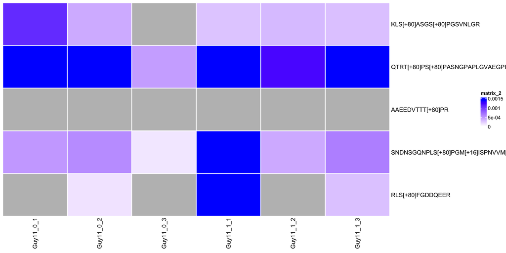

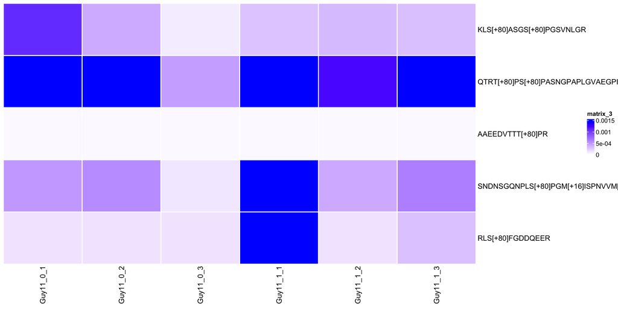

```r
hm_missing
hm_replaced
```

All these replacements look sane to me.

### Output data to excel files for ease

Here I just dump my data objects to an Excel file.

```r
library(writexl)

#cleaned_small
#pdiff

all_mat_dat <- as.data.frame(cbind(mdata$row_info, mdata$data))
sel_cols_missing <- as.data.frame(cbind(mdata$row_info, selected_cols$control, selected_cols$treatment))
sel_cols_replaced <- as.data.frame(m <- cbind(mdata$row_info, control, treatment))

x <- list(
  cleaned_small = cleaned_small,
  loaded_into_pepdiff = pdiff,
  as_matrix_techreps_merged = all_mat_dat,
  selected_cols_missing_values = sel_cols_missing,
  selected_cols_replaced_values = sel_cols_replaced
)

write_xlsx(x, here::here("cleaned","004_all_tables.xlsx"))
```